# Data Visualization with Pandas

Python’s popular data analysis library, pandas, provides several different options for visualizing your data with `.plot()`. Even if you’re at the beginning of your pandas journey, you’ll soon be creating basic plots that will yield valuable insights into your data.

In this session, we are going to visualize data on college majors sourced from the American Community Survey 2010–2012 Public Use Microdata Sample.

```python
import pandas as pd
```

```python
df = pd.read_csv('./recent-grads.csv')
df.head()
```

|  | Rank | Major_code | Major | Total | Men | Women | Major_category | ShareWomen | Sample_size | Employed | ... | Part_time | Full_time_year_round | Unemployed | Unemployment_rate | Median | P25th | P75th | College_jobs | Non_college_jobs | Low_wage_jobs |
| --- | --- | --- | --- | --- | --- | --- | --- | --- | --- | --- | --- | --- | --- | --- | --- | --- | --- | --- | --- | --- | --- |
| 0 | 1 | 2419 | PETROLEUM ENGINEERING | 2339.0 | 2057.0 | 282.0 | Engineering | 0.120564 | 36 | 1976 | ... | 270 | 1207 | 37 | 0.018381 | 110000 | 95000 | 125000 | 1534 | 364 | 193 |
| 1 | 2 | 2416 | MINING AND MINERAL ENGINEERING | 756.0 | 679.0 | 77.0 | Engineering | 0.101852 | 7 | 640 | ... | 170 | 388 | 85 | 0.117241 | 75000 | 55000 | 90000 | 350 | 257 | 50 |
| 2 | 3 | 2415 | METALLURGICAL ENGINEERING | 856.0 | 725.0 | 131.0 | Engineering | 0.153037 | 3 | 648 | ... | 133 | 340 | 16 | 0.024096 | 73000 | 50000 | 105000 | 456 | 176 | 0 |
| 3 | 4 | 2417 | NAVAL ARCHITECTURE AND MARINE ENGINEERING | 1258.0 | 1123.0 | 135.0 | Engineering | 0.107313 | 16 | 758 | ... | 150 | 692 | 40 | 0.050125 | 70000 | 43000 | 80000 | 529 | 102 | 0 |
| 4 | 5 | 2405 | CHEMICAL ENGINEERING | 32260.0 | 21239.0 | 11021.0 | Engineering | 0.341631 | 289 | 25694 | ... | 5180 | 16697 | 1672 | 0.061098 | 65000 | 50000 | 75000 | 18314 | 4440 | 972 |

5 rows × 21 columns

```python
df.tail()
```

|  | Rank | Major_code | Major | Total | Men | Women | Major_category | ShareWomen | Sample_size | Employed | ... | Part_time | Full_time_year_round | Unemployed | Unemployment_rate | Median | P25th | P75th | College_jobs | Non_college_jobs | Low_wage_jobs |
| --- | --- | --- | --- | --- | --- | --- | --- | --- | --- | --- | --- | --- | --- | --- | --- | --- | --- | --- | --- | --- | --- |
| 168 | 169 | 3609 | ZOOLOGY | 8409.0 | 3050.0 | 5359.0 | Biology & Life Science | 0.637293 | 47 | 6259 | ... | 2190 | 3602 | 304 | 0.046320 | 26000 | 20000 | 39000 | 2771 | 2947 | 743 |
| 169 | 170 | 5201 | EDUCATIONAL PSYCHOLOGY | 2854.0 | 522.0 | 2332.0 | Psychology & Social Work | 0.817099 | 7 | 2125 | ... | 572 | 1211 | 148 | 0.065112 | 25000 | 24000 | 34000 | 1488 | 615 | 82 |
| 170 | 171 | 5202 | CLINICAL PSYCHOLOGY | 2838.0 | 568.0 | 2270.0 | Psychology & Social Work | 0.799859 | 13 | 2101 | ... | 648 | 1293 | 368 | 0.149048 | 25000 | 25000 | 40000 | 986 | 870 | 622 |
| 171 | 172 | 5203 | COUNSELING PSYCHOLOGY | 4626.0 | 931.0 | 3695.0 | Psychology & Social Work | 0.798746 | 21 | 3777 | ... | 965 | 2738 | 214 | 0.053621 | 23400 | 19200 | 26000 | 2403 | 1245 | 308 |
| 172 | 173 | 3501 | LIBRARY SCIENCE | 1098.0 | 134.0 | 964.0 | Education | 0.877960 | 2 | 742 | ... | 237 | 410 | 87 | 0.104946 | 22000 | 20000 | 22000 | 288 | 338 | 192 |

5 rows × 21 columns

inline backend for matplotlib is popular for Jupyter Notebooks because it displays the plot in the notebook itself, immediately below the cell that creates the plot:

```python
%matplotlib inline
```

"Median" is the median earnings of full-time, year-round workers and "Rank" is the major’s rank by median earnings.

Let’s start with a plot displaying these columns.

Now you’re ready to make your first plot! You can do so with `.plot()`:

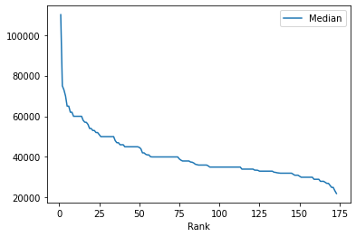

```python
df.plot(x="Rank", y="Median")
```

Looking at the plot, you can make the following observations:

- "area" is for area plots.
- "bar" is for vertical bar charts.
- "barh" is for horizontal bar charts.
- "hist" is for histograms.
- "density" is an alias for "kde".
- "line" is for line graphs.
- "pie" is for pie charts.
- "scatter" is for scatter plots.

The default value is "line". Line graphs, like the one you created above, provide a good overview of your data. You can use them to detect general trends.

`.plot()` is a wrapper for `pyplot.plot()`, and the result is a graph identical to the one you produced with Matplotlib:

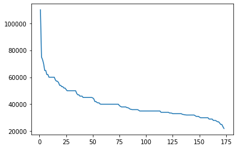

```python
import matplotlib.pyplot as plt

plt.plot(df["Rank"], df["Median"])
```

A histogram is a good way to visualize how values are distributed across a dataset. Histograms group values into bins and display a count of the data points whose values are in a particular bin.

Let’s create a histogram for the "Median" column:

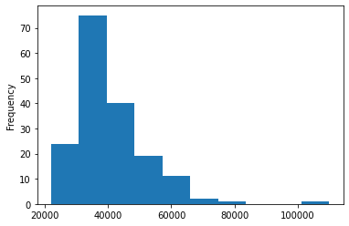

```python
df["Median"].plot(kind="hist")
```

The histogram of the median data, however, peaks on the left below 40,000. The tail stretches far to the right and suggests that there are indeed fields whose majors can expect significantly higher earnings.

Let’s create a new DataFrame called `top_5`by selecting the five majors with the highest median earnings:

```python
top_5 = df.sort_values(by="Median", ascending=False).head()
```

```python
top_5
```

|  | Rank | Major_code | Major | Total | Men | Women | Major_category | ShareWomen | Sample_size | Employed | ... | Part_time | Full_time_year_round | Unemployed | Unemployment_rate | Median | P25th | P75th | College_jobs | Non_college_jobs | Low_wage_jobs |
| --- | --- | --- | --- | --- | --- | --- | --- | --- | --- | --- | --- | --- | --- | --- | --- | --- | --- | --- | --- | --- | --- |
| 0 | 1 | 2419 | PETROLEUM ENGINEERING | 2339.0 | 2057.0 | 282.0 | Engineering | 0.120564 | 36 | 1976 | ... | 270 | 1207 | 37 | 0.018381 | 110000 | 95000 | 125000 | 1534 | 364 | 193 |
| 1 | 2 | 2416 | MINING AND MINERAL ENGINEERING | 756.0 | 679.0 | 77.0 | Engineering | 0.101852 | 7 | 640 | ... | 170 | 388 | 85 | 0.117241 | 75000 | 55000 | 90000 | 350 | 257 | 50 |
| 2 | 3 | 2415 | METALLURGICAL ENGINEERING | 856.0 | 725.0 | 131.0 | Engineering | 0.153037 | 3 | 648 | ... | 133 | 340 | 16 | 0.024096 | 73000 | 50000 | 105000 | 456 | 176 | 0 |
| 3 | 4 | 2417 | NAVAL ARCHITECTURE AND MARINE ENGINEERING | 1258.0 | 1123.0 | 135.0 | Engineering | 0.107313 | 16 | 758 | ... | 150 | 692 | 40 | 0.050125 | 70000 | 43000 | 80000 | 529 | 102 | 0 |
| 4 | 5 | 2405 | CHEMICAL ENGINEERING | 32260.0 | 21239.0 | 11021.0 | Engineering | 0.341631 | 289 | 25694 | ... | 5180 | 16697 | 1672 | 0.061098 | 65000 | 50000 | 75000 | 18314 | 4440 | 972 |

5 rows × 21 columns

Now you have a smaller DataFrame containing only the top five most lucrative majors. As a next step, you can create a bar plot that shows only the majors with these top five median salaries:

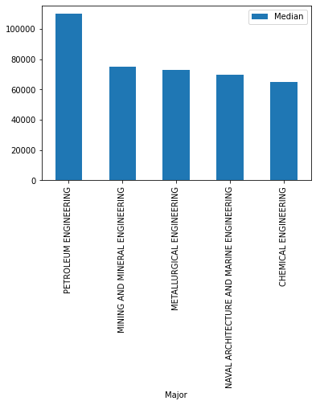

```python
top_5.plot(x="Major", y="Median", kind="bar", rot=90)
```

This plot shows that the median salary of petroleum engineering majors is more than 20,000 USD higher than the rest. The earnings for the second- through fourth-place majors are relatively close to one another.

```python
top_medians = df[df["Median"] > 60000].sort_values("Median")
```

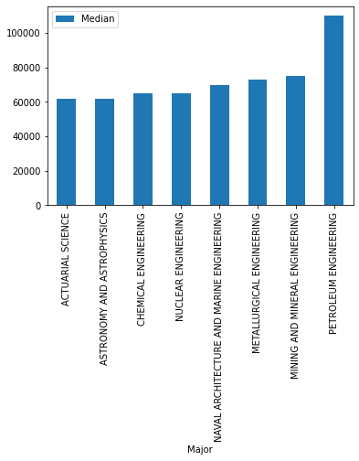

```python
top_medians.plot(x="Major", y="Median", kind="bar")
```

Often you want to see whether two columns of a dataset are connected. If you pick a major with higher median earnings, do you also have a lower chance of unemployment? As a first step, create a scatter plot with those two columns:

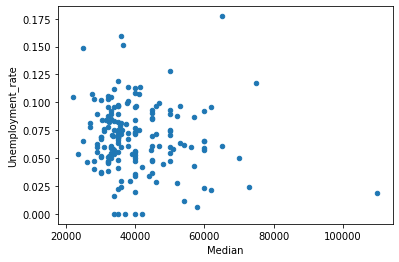

```python
df.plot(x="Median", y="Unemployment_rate", kind="scatter")
```

A quick glance at this figure shows that there’s no significant correlation between the earnings and unemployment rate.

Many datasets already contain some explicit or implicit categorization. In the current example, the 173 majors are divided into 16 categories.

A basic usage of categories is grouping and aggregation. You can use `.groupby()` to determine how popular each of the categories in the college major dataset are:

```python
cat_totals = df.groupby("Major_category")["Total"].sum().sort_values()
cat_totals
```

```
Major_category
Interdisciplinary                        12296.0
Agriculture & Natural Resources          75620.0
Law & Public Policy                     179107.0
Physical Sciences                       185479.0
Industrial Arts & Consumer Services     229792.0
Computers & Mathematics                 299008.0
Arts                                    357130.0
Communications & Journalism             392601.0
Biology & Life Science                  453862.0
Health                                  463230.0
Psychology & Social Work                481007.0
Social Science                          529966.0
Engineering                             537583.0
Education                               559129.0
Humanities & Liberal Arts               713468.0
Business                               1302376.0
Name: Total, dtype: float64
```

With `.groupby()`, you create a DataFrameGroupBy object. With `.sum()`, you create a Series.

Let’s draw a horizontal bar plot showing all the category totals in `cat_totals`:

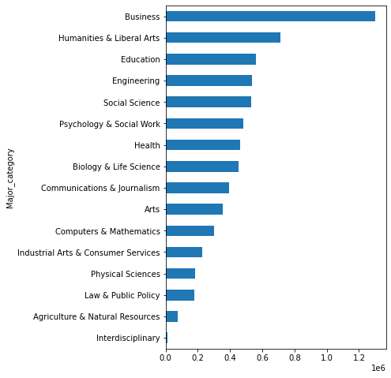

```python
cat_totals.plot(kind="barh",figsize=(5, 8))
```

As your plot shows, business is by far the most popular major category. While humanities and liberal arts is the clear second, the rest of the fields are more similar in popularity.

If you’re interested in ratios, then pie plots are an excellent tool.

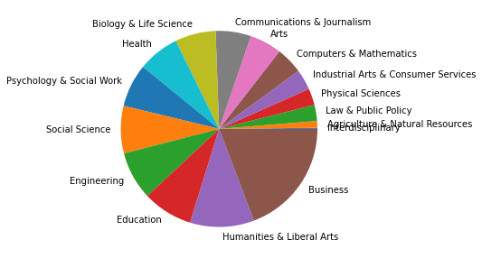

```python
cat_totals.plot(kind="pie",label="",figsize=(5, 5))
```

Lets create a histogram plot showing the distribution of the median earnings for the engineering majors:

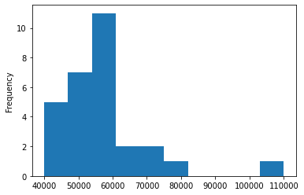

```python
df[df["Major_category"] == "Engineering"]["Median"].plot(kind="hist")
```

```python
Engg = df[df["Major_category"]=="Engineering"]
```

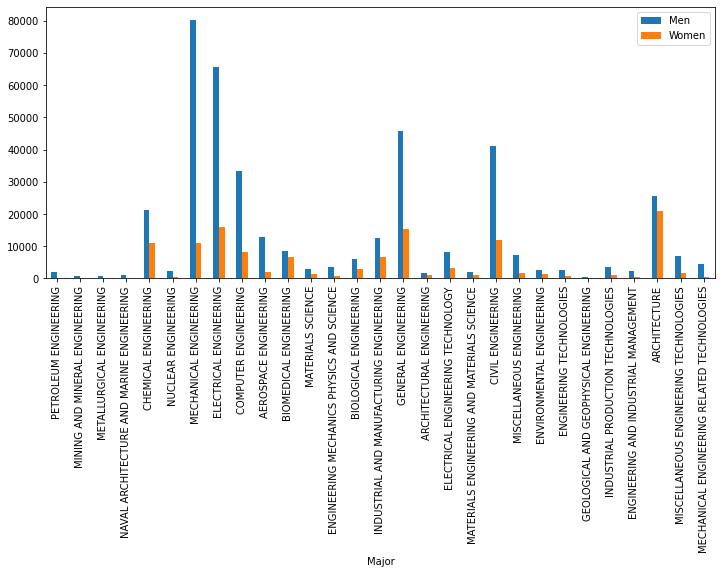

```python
Engg.plot.bar(x='Major',y=['Men','Women'],figsize = (12,5))
```

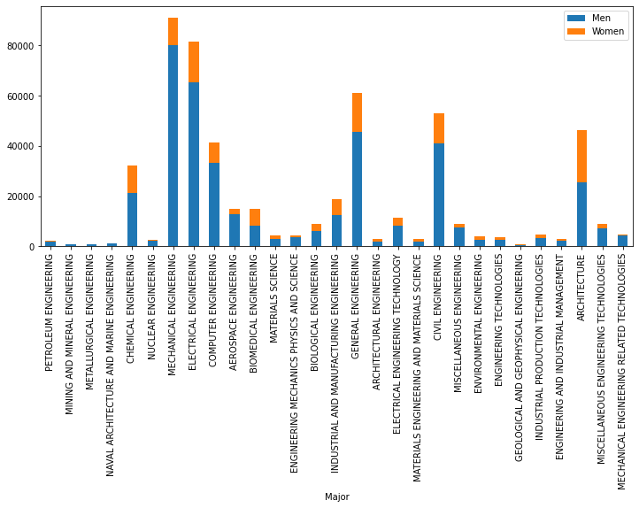

```python
Engg.plot.bar(x='Major',y=['Men','Women'],stacked = True, figsize = (12,5))
```

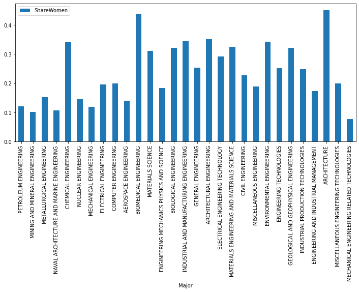

```python
Engg.plot.bar(x='Major',y='ShareWomen',figsize = (12,5))
```

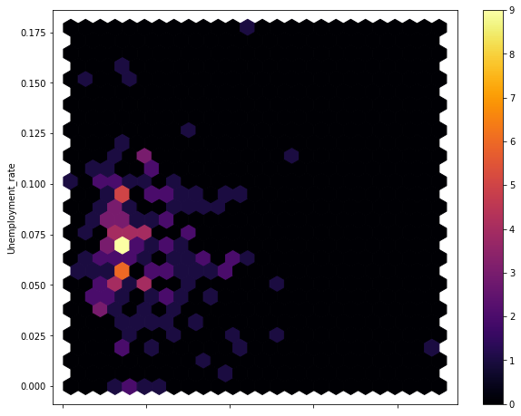

```python
df.plot.hexbin(x ='Median', y ='Unemployment_rate', gridsize = 25, cmap ='inferno',figsize = (10,8))
```